# A1

Mogtaba Alim

2024-02-13

# 1. The Dataset

## A. Dataset Description

The dataset that we are investigating is consolidated from a GEO (Gene Expression Omnibus) series GSE213102. The title of this study is `Molecular mechanisms associated with cis-platin intrinsic resistance in early drug-tolerant persister cells of lung adenocarcinoma cell lines` (Chavez-Dominguez et al. 2023).

Cisplatin is drug used in cancer treatment, and resistance to it is the primary cause for the failure of treatment in lung adenocarcinoma. The cause for this resistance are Drug-tolerant-perisitor (DTP) cells, which can survive the treatment and act as a bank for the emergence of other similarly resistant cells. This experiment investigates the early changes to the DTP cells when exposed to Cisplatin, and trys to establish gene expression signatures associated with the emergence of these cells in lung adenocarcinoma.

I’m very interested in this experiment because it relates to the work I currently do as a researcher. Where in my lab one of the main focuses is pharmacogenomics, which is the study of how drugs affects cells, and particularly cancer cells. I am currently working on creating machine learning models that try and predict cancer prognosis in Non-small Cell Lung Cancer(NSCLC), and so understanding the root cause for the emergence of drug resistant cells, is very important for me.

```r
# loading the counts dataset from GEO into a table
geo_url <- "https://www.ncbi.nlm.nih.gov/geo/download/?format=file&type=rnaseq_counts"
dataset_path <- paste(geo_url, "acc=GSE213102", "file=GSE213102_raw_counts_GRCh38.p13_NCBI.tsv.gz", sep="&");
counts_data <- as.matrix(data.table::fread(dataset_path, header=T, colClasses="integer"), rownames="GeneID")

# loading the gene annotations table
annotation_path <- paste(geo_url, "type=rnaseq_counts", "file=Human.GRCh38.p13.annot.tsv.gz", sep="&")
gene_annotations <- data.table::fread(annotation_path, header=T, quote="", stringsAsFactors=F, data.table=F)

# Defining the row names for the annotations table to be the geneID's
rownames(gene_annotations) <- gene_annotations$GeneID

# The column names for the counts data the first componenet of the name is the
# cell line, the second is the type of experiment where CT is control and CDDP
# is treated with Cisplatin andd the last component is the replicate number
colnames(counts_data) <- c('A549_CT_1', 'A549_CT_2', 'A549_CT_3', 'A549_CDDP_1', 'A549_CDDP_2', 'A549_CDDP_3', 'H1299_CT_1', 'H1299_CT_2', 'H1299_CT_3', 'H1299_CDDP_1', 'H1299_CDDP_2', 'H1299_CDDP_3', 'H1573_CT_1', 'H1573_CT_2', 'H1573_CT_3', 'H1573_CDDP_1', 'H1573_CDDP_2', 'H1573_CDDP_3', '3B1A_CT_1', '3B1A_CT_3', '3B1A_CDDP_1', '3B1A_CDDP_3')

# The counts data
head(counts_data)
```

```
##           A549_CT_1 A549_CT_2 A549_CT_3 A549_CDDP_1 A549_CDDP_2 A549_CDDP_3
## 100287102         2         5        10           8           8          11
## 653635          216       173       382         144         160         290
## 102466751         2         4         2           1           1           1
## 107985730         0         0         0           0           0           1
## 100302278         0         0         0           0           0           0
## 645520            0         0         0           0           0           0
##           H1299_CT_1 H1299_CT_2 H1299_CT_3 H1299_CDDP_1 H1299_CDDP_2
## 100287102         23         22         24           12           13
## 653635           432        646        689          368          463
## 102466751          3          7         16            2            9
## 107985730          0          2          2            1            3
## 100302278          0          0          0            0            1
## 645520             0          0          1            0            2
##           H1299_CDDP_3 H1573_CT_1 H1573_CT_2 H1573_CT_3 H1573_CDDP_1
## 100287102           14          5          4          4            9
## 653635             433        487        517        310          269
## 102466751           10         12         18          1            1
## 107985730            2          0          0          0            0
## 100302278            0          0          0          0            1
## 645520               1          0          0          0            1
##           H1573_CDDP_2 H1573_CDDP_3 3B1A_CT_1 3B1A_CT_3 3B1A_CDDP_1 3B1A_CDDP_3
## 100287102           19            5         5        12          18          12
## 653635             616          303       448       609        1302         423
## 102466751            3            1        10         8          11           6
## 107985730            2            1         1         0           5           1
## 100302278            0            0         0         0           0           0
## 645520               1            1         0         0           0           0
```

```r
# THe annotations data
head(gene_annotations)
```

```
##              GeneID      Symbol                                  Description
## 100287102 100287102     DDX11L1   DEAD/H-box helicase 11 like 1 (pseudogene)
## 653635       653635      WASH7P            WASP family homolog 7, pseudogene
## 102466751 102466751   MIR6859-1                              microRNA 6859-1
## 107985730 107985730 MIR1302-2HG                          MIR1302-2 host gene
## 100302278 100302278   MIR1302-2                              microRNA 1302-2
## 645520       645520     FAM138A family with sequence similarity 138 member A
##                            Synonyms GeneType   EnsemblGeneID Status
## 100287102                             pseudo ENSG00000290825 active
## 653635                FAM39F|WASH5P   pseudo                 active
## 102466751            hsa-mir-6859-1    ncRNA ENSG00000278267 active
## 107985730                              ncRNA                 active
## 100302278 MIRN1302-2|hsa-mir-1302-2    ncRNA ENSG00000284332 active
## 645520                 F379|FAM138F    ncRNA ENSG00000237613 active
##                 ChrAcc ChrStart ChrStop Orientation Length GOFunctionID
## 100287102 NC_000001.11    11874   14409    positive   1652
## 653635    NC_000001.11    14362   29370    negative   1769
## 102466751 NC_000001.11    17369   17436    negative     68
## 107985730 NC_000001.11    29926   31295    positive    538
## 100302278 NC_000001.11    30366   30503    positive    138
## 645520    NC_000001.11    34611   36081    negative   1130
##           GOProcessID GOComponentID GOFunction                     GOProcess
## 100287102
## 653635
## 102466751
## 107985730
## 100302278  GO:0035195                          miRNA-mediated gene silencing
## 645520
##           GOComponent
## 100287102
## 653635
## 102466751
## 107985730
## 100302278
## 645520
```

## B. Explaining the Samples

In the experiment there are 24 different samples

In the original experiment there are 24 different samples. These samples consist of 4 cell lines which are A549, H1299, H1573 and 3B1A. For each of these cell lines the original experiment had 3 control and 3 test replicates. However, in the labeled data that we pulled from Geo2R there are only 22 samples, which is because one control and one test replicate each were removed for the 3B1A cell line.

All cells were harvested by enzymatic treatment with a viability >95%. All the cells were seeded in 96-well plates where the A549 and H1299 cell lines had $1.2\text{x}10^4$ cells and H1573 and 3B1A cell lines had $5\text{x}10^4$ cells.

For the test samples, the cell lines were all treated with serial dilutions of Cisplatin (CDDP) ranging from 5 to 160 $\mu M$ for 24 hours.

# 2. Dataset Statistics and Quality

In this section we will be looking at the dataset statistics. This will allow us to evaluate the quality of the data as well as identify any potential outliers. We will be using the `dplyr` package (Wickham et al. (2023))

## A. General Dataset Statistics

```r
library(dplyr)
counts_data_df <- as.data.frame(counts_data)

# Initialize an empty list to store statistics for each sample
stats_list <- list()

# Iterate over each sample in the counts_data_df
for (sample_name in colnames(counts_data_df)) {
  sample_data <- counts_data_df[[sample_name]]

  # Compute statistics for the sample
  total_counts <- sum(sample_data)
  mean_counts <- mean(sample_data)
  median_counts <- median(sample_data)
  sd_counts <- sd(sample_data)
  var_counts <- var(sample_data)
  genes_detected <- sum(sample_data > 1)

  # Store the statistics in the list
  stats_list[[sample_name]] <- c(total_counts, mean_counts, median_counts, sd_counts, var_counts, genes_detected)
}

# Convert the list of statistics into a data frame
# Each element of the list becomes a row in the new data frame
basic_stats_df <- do.call(rbind, stats_list)
rownames(basic_stats_df) <- names(stats_list)
colnames(basic_stats_df) <- c("Total Counts", "Mean Counts", "Median Counts", "SD Counts", "Variance", "Genes Detected")
```

```r
basic_stats_df
```

```
##              Total Counts Mean Counts Median Counts SD Counts  Variance
## A549_CT_1        26993875    685.5413             1  4257.745  18128393
## A549_CT_2        19598006    497.7145             1  3695.848  13659289
## A549_CT_3        39412753   1000.9334             2  6678.719  44605289
## A549_CDDP_1      15956352    405.2304             1  7637.311  58328515
## A549_CDDP_2      17269117    438.5696             2  8796.522  77378803
## A549_CDDP_3      24011204    609.7929             2 11147.539 124267637
## H1299_CT_1       33953014    862.2769             2  4911.223  24120115
## H1299_CT_2       45363982   1152.0719             3  6863.067  47101683
## H1299_CT_3       41470407   1053.1899             3  6342.065  40221789
## H1299_CDDP_1     25412452    645.3792             2 12994.070 168845855
## H1299_CDDP_2     27371042    695.1199             4 12985.252 168616760
## H1299_CDDP_3     25880769    657.2727             3 12229.567 149562301
## H1573_CT_1       36983942    939.2509             5  4832.302  23351140
## H1573_CT_2       32195665    817.6469             5  4267.917  18215114
## H1573_CT_3       25497196    647.5314             4  3184.901  10143595
## H1573_CDDP_1     13474619    342.2039             3  9118.384  83144928
## H1573_CDDP_2     31421870    797.9955             7 21138.252 446825689
## H1573_CDDP_3     18404640    467.4076             4  8724.063  76109275
## 3B1A_CT_1        28836763    732.3436             3  4307.281  18552672
## 3B1A_CT_3        54181392   1376.0004             5  7195.252  51771654
## 3B1A_CDDP_1      27941861    709.6165             4  9267.823  85892535
## 3B1A_CDDP_3      18153593    461.0319             3  6746.429  45514303
##              Genes Detected
## A549_CT_1             19433
## A549_CT_2             19568
## A549_CT_3             19845
## A549_CDDP_1           18999
## A549_CDDP_2           20350
## A549_CDDP_3           20102
## H1299_CT_1            20209
## H1299_CT_2            21200
## H1299_CT_3            21263
## H1299_CDDP_1          20403
## H1299_CDDP_2          22292
## H1299_CDDP_3          21556
## H1573_CT_1            22674
## H1573_CT_2            22430
## H1573_CT_3            22190
## H1573_CDDP_1          22049
## H1573_CDDP_2          24182
## H1573_CDDP_3          22267
## 3B1A_CT_1             21329
## 3B1A_CT_3             22845
## 3B1A_CDDP_1           22411
## 3B1A_CDDP_3           21603
```

## B. Distribution Visualization

Now that we have seen the basic stats for different samples we will be visualizing our data. 1. A `Boxplot` which will allow us to show the distribution of expression levels for each sample, highlighting the median, interquartile range, and potential outliers.

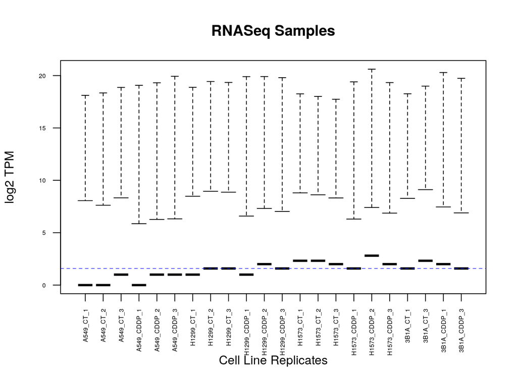

```r
# We take the log of the counts data so that we are able to fit the data in the
# Box plot
dataset_log <- log2(counts_data)

# Plotting our boxplot
# The xlab and ylab are empty because by default they are too small
boxplot(dataset_log, xlab = "", ylab = "",
        las = 2, cex = 0.5, cex.lab = 0.5,
        cex.axis = 0.5, main = "RNASeq Samples")

# We manually add our x and y axis labels to ensure that they are positioned
# correctly in the plot and are visible
title(xlab = "Cell Line Replicates", line = 4)
title(ylab = "log2 TPM")

# The below code draws the median line on the boxplot
abline(h = median(apply(dataset_log, 2, median)),
       col = "blue", lwd = 0.6, lty = "dashed")
```

2. A `density plot` will provide a smooth estimate of the distribution of expression levels across all samples, useful for comparing the overall shape of distributions.

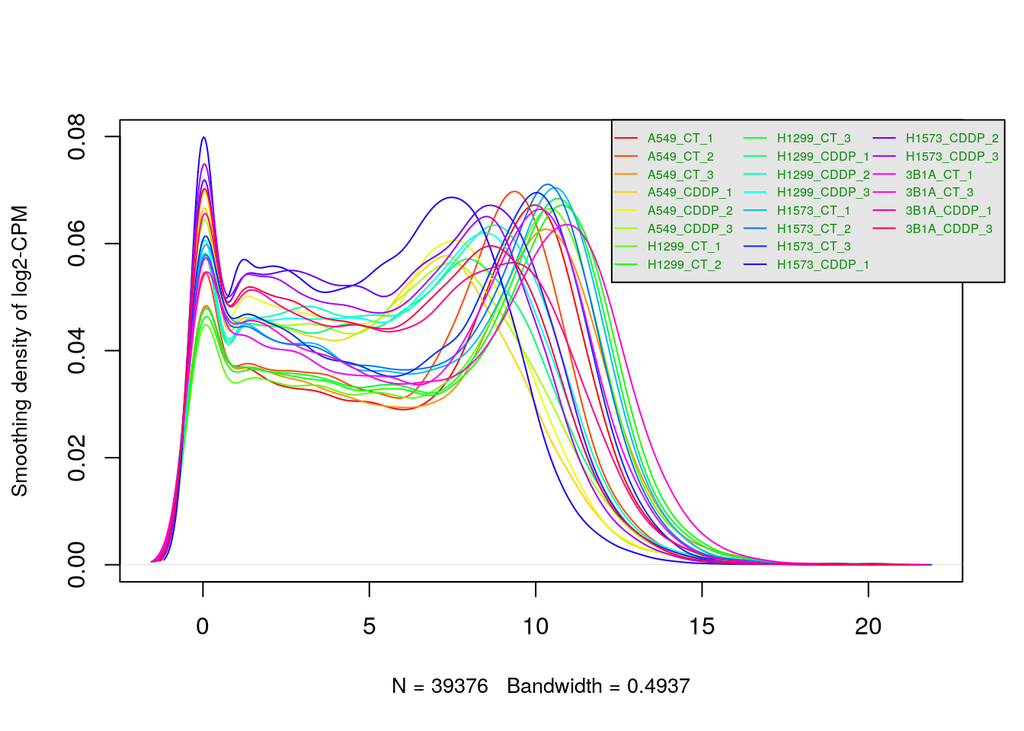

```r
dataset_counts_den <- apply(log2(counts_data), 2, density)

# We calculate the max and minimum across all our sample replicates
xmax <- 0; ymax <- 0
for (i in 1:length(dataset_counts_den)) {
    xmax <- range(c(xmax, dataset_counts_den[[i]]$x))
    ymax <- range(c(ymax, dataset_counts_den[[i]]$y))
}

column_vals <- rainbow(length(dataset_counts_den))
lty_vals <- rep(1, length(dataset_counts_den))

# We first initialize our density plot by plotting the first density plot
plot(dataset_counts_den[[1]], xlim=xmax, ylim=ymax, type="n",
     ylab="Smoothing density of log2-CPM", main="", cex.lab = 0.85)

# Then we ensure that each line is plotted
for (i in 1:length(dataset_counts_den)) {
    lines(dataset_counts_den[[i]], col=column_vals[i], lty=lty_vals[i])
}

# Lastly we create our legend
# We had to modify our legend a lot from standard because
# we have 22 samples and onlny 17 of them would fit.

# Increase the bottom margin to make space for the legend
par(mar=c(8, 4, 4, 2) + 0.1, xpd=TRUE)

# Create the legend at the bottom of the plot
legend("topright", inset=c(-0.05, 0),  # Adjust the inset to move the legend below the plot
       legend = colnames(dataset_log), col = column_vals, lty = lty_vals, cex = 0.5,
       border = "blue", text.col = "green4",
       merge = TRUE, bg = "gray90", ncol = 3)
```

# 3. Dataset Filtering and Standardization

We see that we start with 39376 values in our dataset pre-filtering. This number is a further reduction from the original 58786 that was in the original dataset that had no gene identifiers. The current number of 39376 is the number of genes that were used in the analysis on Geo2R. Filtering the Dataset In this section we will be filtering the dataset. This includes identifying duplicate expressions, removing expressions with low counts per million (cpm) and finally ensuring that all gene names are HGNC compliant.

## A. Duplicate Identification

```r
# Find the duplicate row names
dup_rows <- rownames(counts_data_df)[duplicated(rownames(counts_data_df))]

# Remove rows with duplicate names
counts_data_unique <- counts_data_df[!rownames(counts_data_df) %in% dup_rows, ]

print("The number of duplicate rows:")
```

```
## [1] "The number of duplicate rows:"
```

```r
length(counts_data_unique) - length(counts_data_df)
```

```
## [1] 0
```

We can see from our code that we do not have any duplicate expressions in our dataset.

## B. Removing Low CPM Expressions

We will be using the `edgeR` package for our CPM calculations and filtering (Robinson, McCarthy, and Smyth (2010))

```r
library(edgeR)
# The knockdown value which represents the replicate number for the condition
# with the lowest number of replicates
kd_val = 2

# We use our dataset to calculate the CPM
dataset_cpm <- edgeR::cpm(counts_data)

# Identify the rows that pass our threshold
pass_thold <- rowSums(dataset_cpm > 1) >= kd_val

# Create a new dataset of counts after expressions with low cpm are removed
filtered_counts <- counts_data[pass_thold,]

print("These are the number of expressions that did not pass our threshold for CPM")
```

```
## [1] "These are the number of expressions that did not pass our threshold for CPM"
```

```r
nrow(counts_data) - nrow(filtered_counts)
```

```
## [1] 20324
```

```r
print("This is the number of expressions remaining aftering filtering")
```

```
## [1] "This is the number of expressions remaining aftering filtering"
```

```r
nrow(filtered_counts)
```

```
## [1] 19052
```

For our dataset we filtered out the genes that had low cpm. First we filtered only the expressions that had a cpm greater than 1. Then we further filtered it so that expressions where genes where the sum of expressions across the samples was less than the knockdown number which is the lowest numbero f replicate for a cell line, were removed.

## C. Replicates

In this experiment for each of the cell lines there were 3 replicates for the control and 3 replicates for the cell lines treated with CPPD, with the exception of 3B1A which only had 2 replicates for each.

In our experiment we did not remove replicates but instead treated them as independent. This is because this would make our expriment much richer, given that we have multiple samples to analyze and becayse from our graph of data pre-filtering we saw that the expression counts were not extremly similar when it comes to the replicates.

## D. Standardize gene names with HUGO

In this section we will be mapping the gene identifiers to HUGO Symbols. This will allow us to standardize the gene names. We will also identify the number of genes that either do not have HUGO symbols and if ones do if there are more updated names.

```r
# Create a named vector for mapping gene numbers to gene symbols
gene_to_symbol <- gene_annotations$Symbol
names(gene_to_symbol) <- gene_annotations$GeneID

# Replace the row names in filtered_counts with the corresponding gene symbols
# 'match' function is used to find the index of the gene numbers in the named vector
rownames(filtered_counts) <- gene_to_symbol[match(rownames(filtered_counts), names(gene_to_symbol))]

# If there are gene numbers that don't have a corresponding symbol, they will be replaced with NA.
missing_symbols <- is.na(rownames(filtered_counts))
rownames(filtered_counts)[missing_symbols] <- names(missing_symbols)[missing_symbols]

head(filtered_counts)
```

```
##              A549_CT_1 A549_CT_2 A549_CT_3 A549_CDDP_1 A549_CDDP_2 A549_CDDP_3
## WASH7P             216       173       382         144         160         290
## LOC100996442        33        28        42          12          19          18
## LOC729737           33        41        46           8           9          17
## DDX11L17             4         7        21          11           7          17
## WASH9P             282       202       474         184         195         342
## LOC112268260         8         4         8           3           6           7
##              H1299_CT_1 H1299_CT_2 H1299_CT_3 H1299_CDDP_1 H1299_CDDP_2
## WASH7P              432        646        689          368          463
## LOC100996442         34         57         41           15           24
## LOC729737           210        369        338           64          153
## DDX11L17             48         40         49           19           18
## WASH9P              585        863        898          518          620
## LOC112268260         13         13         15            6            6
##              H1299_CDDP_3 H1573_CT_1 H1573_CT_2 H1573_CT_3 H1573_CDDP_1
## WASH7P                433        487        517        310          269
## LOC100996442           18         78         74         59           28
## LOC729737              86        733        559        422          238
## DDX11L17               23          3          3          5            9
## WASH9P                620        638        646        390          338
## LOC112268260            4         25         23         48           14
##              H1573_CDDP_2 H1573_CDDP_3 3B1A_CT_1 3B1A_CT_3 3B1A_CDDP_1
## WASH7P                616          303       448       609        1302
## LOC100996442           60           33        22        47          13
## LOC729737             385          140        58        67          32
## DDX11L17               17            5         9        13          19
## WASH9P                851          413       477       647        1535
## LOC112268260           21           21         7        12           6
##              3B1A_CDDP_3
## WASH7P               423
## LOC100996442          10
## LOC729737             14
## DDX11L17              12
## WASH9P               453
## LOC112268260           4
```

```r
# Count the number of rows with NA as the row name
num_rows_with_na <- sum(is.na(rownames(filtered_counts)))

# Output the number
num_rows_with_na
```

```
## [1] 0
```

## E. Dataset Statistics and Distribution Plots

We will now re-calculate the statistics for our dataset post filtering, as well as plot the graphs of the counts sample distribution.

### i.Genereal Statistics

```r
filtered_counts_df <- as.data.frame(filtered_counts)

# Initialize an empty list to store statistics for each sample
filtered_stats_list <- list()

# Iterate over each sample in the filtered_counts_df
for (sample_name in colnames(filtered_counts_df)) {
  sample_data <- filtered_counts_df[[sample_name]]

  # Compute statistics for the sample
  total_counts <- sum(sample_data)
  mean_counts <- mean(sample_data)
  median_counts <- median(sample_data)
  sd_counts <- sd(sample_data)
  var_counts <- var(sample_data)
  genes_detected <- sum(sample_data > 1)

  # Store the statistics in the list
  filtered_stats_list[[sample_name]] <- c(total_counts, mean_counts, median_counts, sd_counts, var_counts, genes_detected)
}

# Convert the list of statistics into a data frame
# Each element of the list becomes a row in the new data frame
filtered_stats_df <- do.call(rbind, filtered_stats_list)
rownames(filtered_stats_df) <- names(filtered_stats_list)
colnames(filtered_stats_df) <- c("Total Counts", "Mean Counts", "Median Counts", "SD Counts", "Variance", "Genes Detected")

filtered_stats_df
```

```
##              Total Counts Mean Counts Median Counts SD Counts  Variance
## A549_CT_1        26978079   1416.0235         302.5  6036.080  36434262
## A549_CT_2        19582365   1027.8378         222.0  5261.824  27686793
## A549_CT_3        39392841   2067.6486         368.5  9486.119  89986447
## A549_CDDP_1      15946073    836.9763          65.0 10963.276 120193415
## A549_CDDP_2      17252743    905.5607          87.0 12629.551 159505568
## A549_CDDP_3      23994384   1259.4155          89.0 16000.664 256021260
## H1299_CT_1       33930220   1780.9269         404.0  6943.834  48216833
## H1299_CT_2       45330575   2379.3079         559.0  9717.644  94432595
## H1299_CT_3       41437507   2174.9689         526.0  8982.931  80693052
## H1299_CDDP_1     25394631   1332.9116         108.0 18656.319 348058226
## H1299_CDDP_2     27333464   1434.6769         175.0 18639.766 347440864
## H1299_CDDP_3     25852947   1356.9676         144.5 17554.768 308169883
## H1573_CT_1       36948024   1939.3252         506.0  6806.232  46324792
## H1573_CT_2       32162822   1688.1599         441.0  6014.908  36179118
## H1573_CT_3       25467937   1336.7592         354.0  4477.118  20044586
## H1573_CDDP_1     13453104    706.1256          86.0 13099.200 171589044
## H1573_CDDP_2     31377670   1646.9489         187.0 30366.299 922112125
## H1573_CDDP_3     18380887    964.7747         129.0 12522.976 156824920
## 3B1A_CT_1        28807444   1512.0430         352.0  6096.486  37167146
## 3B1A_CT_3        54131254   2841.2374         626.0 10141.152 102842967
## 3B1A_CDDP_1      27904578   1464.6535         196.0 13282.315 176419891
## 3B1A_CDDP_3      18130206    951.6169         133.0  9674.894  93603583
##              Genes Detected
## A549_CT_1             17063
## A549_CT_2             17061
## A549_CT_3             17154
## A549_CDDP_1           16889
## A549_CDDP_2           17231
## A549_CDDP_3           17182
## H1299_CT_1            17276
## H1299_CT_2            17573
## H1299_CT_3            17574
## H1299_CDDP_1          17244
## H1299_CDDP_2          17617
## H1299_CDDP_3          17486
## H1573_CT_1            18218
## H1573_CT_2            18192
## H1573_CT_3            18178
## H1573_CDDP_1          18000
## H1573_CDDP_2          18374
## H1573_CDDP_3          18089
## 3B1A_CT_1             17589
## 3B1A_CT_3             17942
## 3B1A_CDDP_1           17834
## 3B1A_CDDP_3           17705
```

### ii. Distribution Plots

1. `Boxplot`

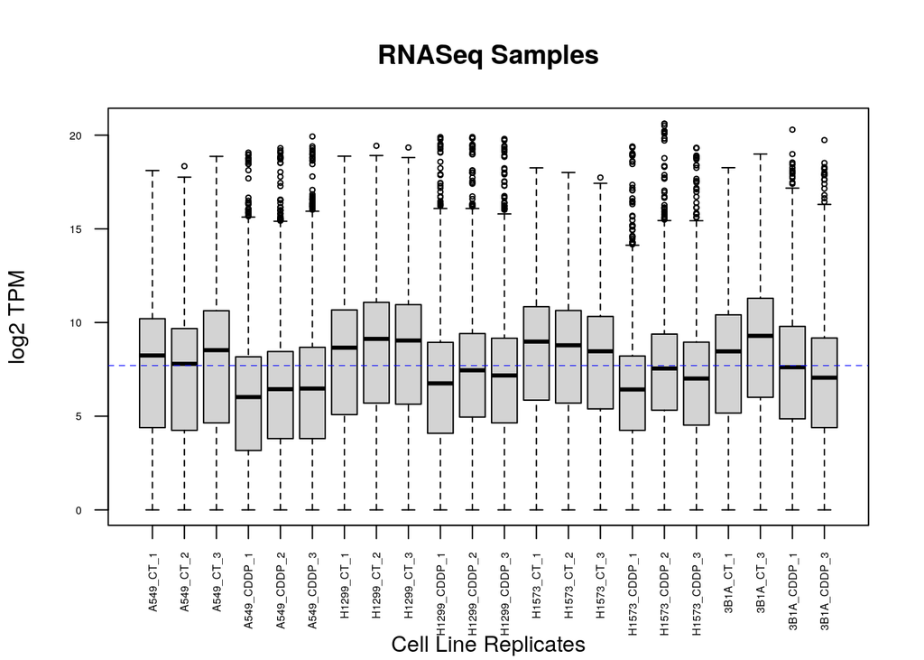

```r
# We take the log of the filtered counts data so that we are able to fit the
# data in the Box plot
filtered_dataset_log <- log2(filtered_counts_df)

# Plotting our boxplot
# The xlab and ylab are empty because by default they are too small
boxplot(filtered_dataset_log, xlab = "", ylab = "",
        las = 2, cex = 0.5, cex.lab = 0.5,
        cex.axis = 0.5, main = "RNASeq Samples")

# We manually add our x and y axis labels to ensure that they are positioned
# correctly in the plot and are visible
title(xlab = "Cell Line Replicates", line = 4)
title(ylab = "log2 TPM")

# The below code draws the median line on the boxplot
abline(h = median(apply(filtered_dataset_log, 2, median)),
       col = "blue", lwd = 0.6, lty = "dashed")
```

2. `Density Plot`

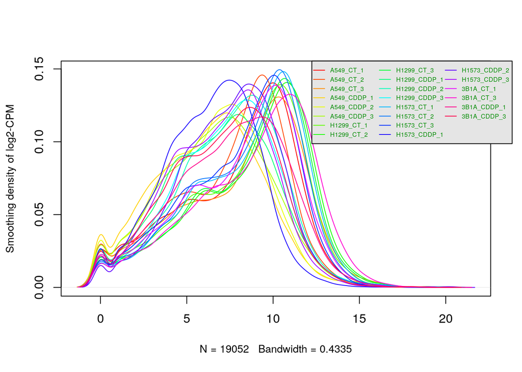

```r
filtered_counts_den <- apply(log2(filtered_counts_df), 2, density)

# We calculate the max and minimum across all our sample reolicates
xmax <- 0; ymax <- 0
for (i in 1:length(filtered_counts_den)) {
    xmax <- range(c(xmax, filtered_counts_den[[i]]$x))
    ymax <- range(c(ymax, filtered_counts_den[[i]]$y))
}

column_vals <- rainbow(length(filtered_counts_den))
lty_vals <- rep(1, length(filtered_counts_den))

# We first initialize our density plot by plotting the first density plot
plot(filtered_counts_den[[1]], xlim=xmax, ylim=ymax, type="n",
     ylab="Smoothing density of log2-CPM", main="", cex.lab = 0.85)

# Then we ensure that each line is plotted
for (i in 1:length(filtered_counts_den)) {
    lines(filtered_counts_den[[i]], col=column_vals[i], lty=lty_vals[i])
}

# Lastly we create our legend
# We had to modify our legend a lot from standard because
# we have 22 samples and onlny 17 of them would fit.

# Increase the bottom margin to make space for the legend
par(mar=c(8, 4, 4, 2) + 0.1, xpd=TRUE)

# Create the legend at the bottom of the plot
legend("topright", inset=c(-0.05, 0),  # Adjust the inset to move the legend below the plot
       legend = colnames(filtered_dataset_log), col = column_vals, lty = lty_vals, cex = 0.5,
       border = "blue", text.col = "green4",
       merge = TRUE, bg = "gray90", ncol = 3)
```

## F. Outlier Identification

From our graphs above, especially the box plot we can clearly identify outliers in our samples. These outliers are greatly visible and abundant for the samples that are treated with CDDP. Where we see many outliers for these samples.

Although we have many outliers in these samples we will not be removing them, this is because on analysis of the paper there does not seem to be any experimental issues or shortcomings described, therefore we are not able to conclude that the outliers are not part of the actual experimental data and that they are due to issues in th experimental procedure.

# 4. Normalization

For this dataset we will be using the Trimmed Mean of M-values (TMM) method to normalize our data. This is because this method corrects for situations where the presence of highly expressed genes in one sample can disproportionately affect the overall library size, leading to misleading comparisons across samples (Abbas-Aghababazadeh, Li, and Fridley (2018))

By trimming or ignoring the most extreme M-values (log-ratios of expression), TMM normalization minimizes the influence of outliers or genes with extreme expression differences (“Normalisation Strategies for Differential Gene Expression” (n.d.))

## A. TMM

The following chunk contains the code for TMM normalization it was inspired by a forum from biostars (Smyth (n.d.))

```r
# Store the HUGO gene Symbols
gene_symbols <- rownames(filtered_counts_df)

# Create a DGEList object
dge <- edgeR::DGEList(counts = filtered_counts_df, genes = gene_symbols)

# Calculate the normalization factors using the TMM
dge <- edgeR::calcNormFactors(dge, method = "TMM")

# Compute normalized counts
norm_counts <- edgeR::cpm(dge, log = FALSE)

head(norm_counts)
```

```
##              A549_CT_1 A549_CT_2  A549_CT_3 A549_CDDP_1 A549_CDDP_2 A549_CDDP_3
## WASH7P       6.8677045 7.4929621  9.0474144  14.0931501  12.8508751  20.1271423
## LOC100996442 1.0492326 1.2127338  0.9947419   1.1744292   1.5260414   1.2492709
## LOC729737    1.0492326 1.7757887  1.0894792   0.7829528   0.7228617   1.1798670
## DDX11L17     0.1271797 0.3031834  0.4973709   1.0765601   0.5622258   1.1798670
## WASH9P       8.9661698 8.7490078 11.2263728  18.0079141  15.6620040  23.7361471
## LOC112268260 0.2543594 0.1732477  0.1894746   0.2936073   0.4819078   0.4858276
##              H1299_CT_1 H1299_CT_2 H1299_CT_3 H1299_CDDP_1 H1299_CDDP_2
## WASH7P        9.6721914 11.0416094 12.5162996   21.9478401   19.1905236
## LOC100996442  0.7612373  0.9742597  0.7448016    0.8946130    0.9947572
## LOC729737     4.7017597  6.3070493  6.1400715    3.8170157    6.3415769
## DDX11L17      1.0746879  0.6836910  0.8901287    1.1331765    0.7460679
## WASH9P       13.0977591 14.7506330 16.3129710   30.8939706   25.6978934
## LOC112268260  0.2910613  0.2221996  0.2724884    0.3578452    0.2486893
##              H1299_CDDP_3  H1573_CT_1  H1573_CT_2 H1573_CT_3 H1573_CDDP_1
## WASH7P         21.1156651  9.62681809 11.65607685  8.8150412   24.5510840
## LOC100996442    0.8777875  1.54187230  1.66837464  1.6777014    2.5555032
## LOC729737       4.1938734 14.48964612 12.60299218 11.9998303   21.7217770
## DDX11L17        1.1216173  0.05930278  0.06763681  0.1421781    0.8214117
## WASH9P         30.2349016 12.61172472 14.56445966 11.0898906   30.8485740
## LOC112268260    0.1950639  0.49418984  0.51854887  1.3649096    1.2777516
##              H1573_CDDP_2 H1573_CDDP_3  3B1A_CT_1 3B1A_CT_3 3B1A_CDDP_1
## WASH7P         25.8189178   17.9277728 11.9079838 9.1968456   47.448783
## LOC100996442    2.5148297    1.9525297  0.5847671 0.7097730    0.473759
## LOC729737      16.1368236    8.2834594  1.5416586 1.0118040    1.166176
## DDX11L17        0.7125351    0.2958378  0.2392229 0.1963202    0.692417
## WASH9P         35.6686673   24.4362051 12.6788131 9.7707047   55.940001
## LOC112268260    0.8801904    1.2425189  0.1860622 0.1812186    0.218658
##              3B1A_CDDP_3
## WASH7P        23.2252582
## LOC100996442   0.5490605
## LOC729737      0.7686847
## DDX11L17       0.6588726
## WASH9P        24.8724396
## LOC112268260   0.2196242
```

## B. Visualization

1. `MDS` or Multidimension Scaling is a data analysis techinique that is used to represent the closeness in relationship of two objects. What it does is allow us to represent the similarity or disimilarity of objects in our data (Z. Zhang (2010)).

We will be using the limma library to plot our MDS graph (Ritchie et al. (2015))

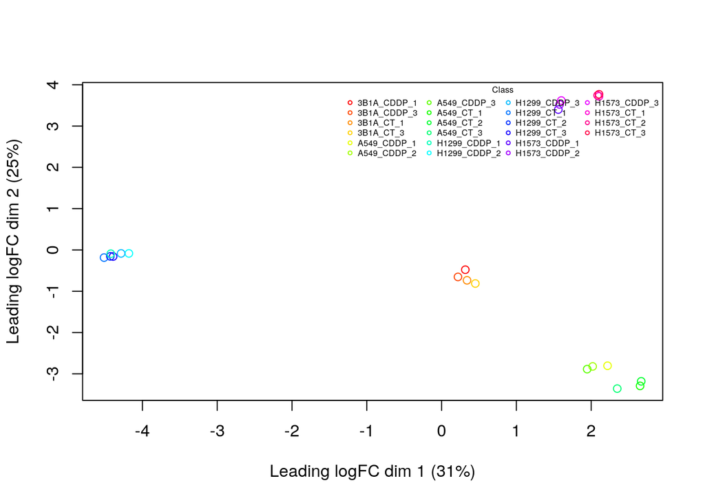

```r
library(limma)

# We create a gradient rainbow vector for the column names
col_vector <- rainbow(ncol(dge))

# We plot the MDS
limma::plotMDS(dge, labels=NULL, pch = 1,
               col = col_vector[factor(colnames(dge))])

# We create the legend and divide it into 4 columns as the number of samples
# is too big
legend("topright",
       legend=levels(factor(colnames(dge))),
       pch=c(1), col= col_vector,title="Class",
       bty = 'n', cex = 0.5, ncol = 4)
```

2. `Boxplot`

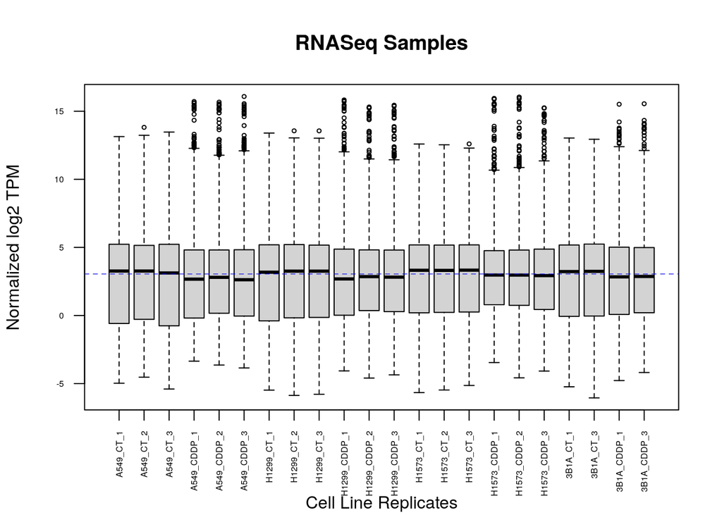

```r
# We take the log of the normalized counts data so that we are able to fit the
# data in the Box plot
normalized_dataset_log <- log2(norm_counts)

# Plotting our boxplot
# The xlab and ylab are empty because by default they are too small
boxplot(normalized_dataset_log, xlab = "", ylab = "",
        las = 2, cex = 0.5, cex.lab = 0.5,
        cex.axis = 0.5, main = "RNASeq Samples")

# We manually add our x and y axis labels to ensure that they are positioned
# correctly in the plot and are visible
title(xlab = "Cell Line Replicates", line = 4)
title(ylab = "Normalized log2 TPM")

# The below code draws the median line on the boxplot
abline(h = median(apply(normalized_dataset_log, 2, median)),
       col = "blue", lwd = 0.6, lty = "dashed")
```

3. `Density plot`

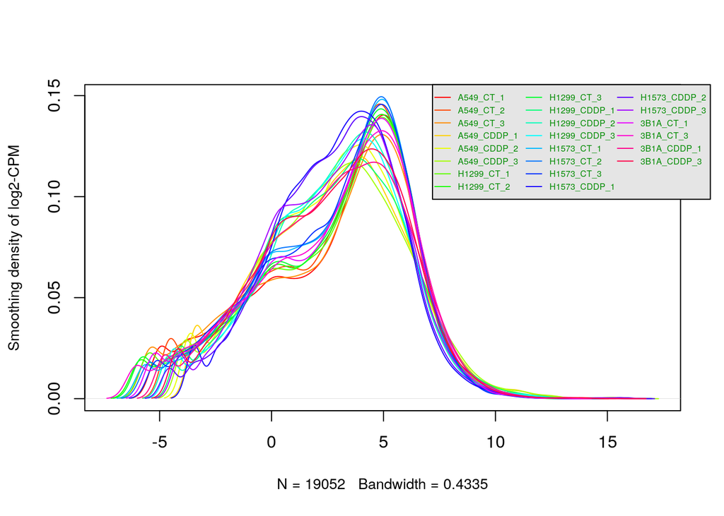

```r
norm_counts_den <- apply(log2(norm_counts), 2, density)

# We calculate the max and minimum across all our sample reolicates
xmax <- 0; ymax <- 0
for (i in 1:length(norm_counts_den)) {
    xmax <- range(c(xmax, norm_counts_den[[i]]$x))
    ymax <- range(c(ymax, norm_counts_den[[i]]$y))
}

column_vals <- rainbow(length(norm_counts_den))
lty_vals <- rep(1, length(norm_counts_den))

# We first initialize our density plot by plotting the first density plot
plot(norm_counts_den[[1]], xlim=xmax, ylim=ymax, type="n",
     ylab="Smoothing density of log2-CPM", main="", cex.lab = 0.85)

# Then we ensure that each line is plotted
for (i in 1:length(norm_counts_den)) {
    lines(norm_counts_den[[i]], col=column_vals[i], lty=lty_vals[i])
}

# Lastly we create our legend
# We had to modify our legend a lot from standard because
# we have 22 samples and onlny 17 of them would fit.

# Increase the bottom margin to make space for the legend
par(mar=c(8, 4, 4, 2) + 0.1, xpd=TRUE)

# Create the legend at the bottom of the plot
legend("topright", inset=c(-0.05, 0),  # Adjust the inset to move the legend below the plot
       legend = colnames(normalized_dataset_log), col = column_vals, lty = lty_vals, cex = 0.5,
       border = "blue", text.col = "green4",
       merge = TRUE, bg = "gray90", ncol = 3)
```

4. `Dispersion`. This allows to describe the amount of difference between our mean and our variance. We are displaying three types of despersion, the first is tagwise dispersion which calculates the dispersion for each gene individually, and the second is common dispersion which is a combined measure of dispersion for all the genes and the last type of dispersion is estimating gene-specific dispersion that is moderated towards a trend based on the average expression levels of genes.

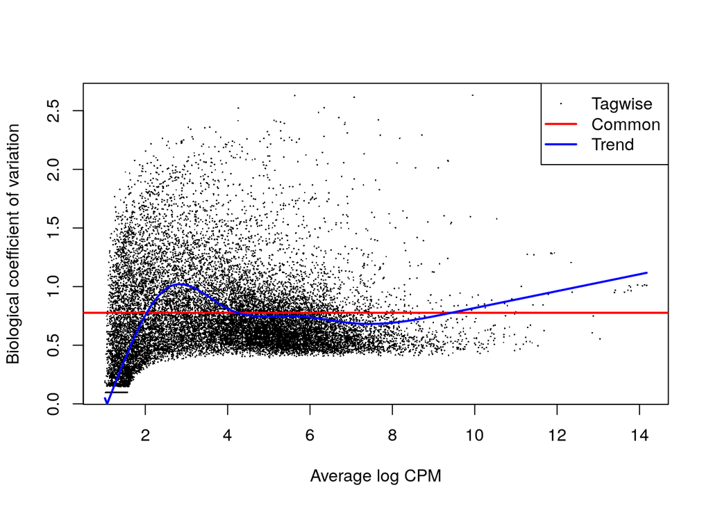

```r
# Create a DGEList object
disp_norm_dge <- edgeR::DGEList(counts = norm_counts, genes = gene_symbols)

# Estimate the Common Dispersion
disp_norm_dge <- edgeR::estimateCommonDisp(disp_norm_dge)

# Estimate the Tagwise Dispersion
disp_norm_dge <- edgeR::estimateTagwiseDisp(disp_norm_dge)

# Estimate the Trended Dispersion
disp_norm_dge <- edgeR::estimateTrendedDisp(disp_norm_dge)

edgeR::plotBCV(disp_norm_dge, col.tagwise = "black", col.common = "red", col.trend = "blue")
```

5. `Mean-Variance Plot`. This plot allows us to measure the change in the variance of a dataset with respect to mean. This helps us understand whether genes with higher or lower expression levels tend to be more or less variable. It also allows us to identify possible appropriate data transformation or statistical models that account for this relationship. The plot can reveal data characteristics that might need addressing, for example we often expect the variance of dataset to increase in the mean when it comes to biological data. (Mar et al. 2011)

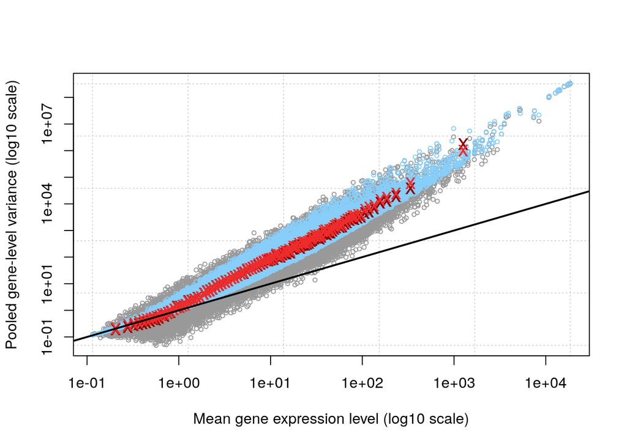

```r
edgeR::plotMeanVar(disp_norm_dge, show.raw.vars = TRUE, show.tagwise.vars=TRUE,
            show.ave.raw.vars = TRUE, NBline=FALSE,
            show.binned.common.disp.vars = TRUE)
```

# 5. References

Abbas-Aghababazadeh, Farnoosh, Qian Li, and Brooke L. Fridley. 2018. “Comparison of Normalization Approaches for Gene Expression Studies Completed with High-Throughput Sequencing.” *PloS One* 13 (10): e0206312. https://doi.org/10.1371/journal.pone.0206312.

Chavez-Dominguez, Rodolfo, Dolores Aguilar-Cazares, Mario Perez-Medina, Santiago Avila-Rios, Maribel Soto-Nava, Alfonso Mendez-Tenorio, Lorenzo Islas-Vazquez, Jesus J. Benito-Lopez, Miriam Galicia-Velasco, and Jose S. Lopez-Gonzalez. 2023. “Transcriptional Signature of Early Cisplatin Drug-Tolerant Persister Cells in Lung Adenocarcinoma.” *Frontiers in Oncology* 13. https://doi.org/10.3389/fonc.2023.1208403.

Mar, Jessica C., Nicholas A. Matigian, Alan Mackay-Sim, George D. Mellick, Carolyn M. Sue, Peter A. Silburn, John J. McGrath, John Quackenbush, and Christine A. Wells. 2011. “Variance of Gene Expression Identifies Altered Network Constraints in Neurological Disease.” *PLoS Genetics* 7 (8): e1002207. https://doi.org/10.1371/journal.pgen.1002207.

“Normalisation Strategies for Differential Gene Expression.” n.d. *Rpubs.com*. https://rpubs.com/Nishapaudel/normalisation_for_differential_gene_expression.

Ritchie, Matthew E, Belinda Phipson, Di Wu, Yifang Hu, Charity W Law, Wei Shi, and Gordon K Smyth. 2015. “limma Powers Differential Expression Analyses for RNA-Sequencing and Microarray Studies.” *Nucleic Acids Research* 43 (7): e47. https://doi.org/10.1093/nar/gkv007.

Robinson, Mark D, Davis J McCarthy, and Gordon K Smyth. 2010. “edgeR: A Bioconductor Package for Differential Expression Analysis of Digital Gene Expression Data.” *Bioinformatics* 26 (1): 139–40. https://doi.org/10.1093/bioinformatics/btp616.

Smyth, Gordon. n.d. “How Do You Generate TMM Normalized Counts Using EdgeR?” *Biostars.org*. https://www.biostars.org/p/9475236/.

Wickham, Hadley, Romain François, Lionel Henry, Kirill Müller, and Davis Vaughan. 2023. *Dplyr: A Grammar of Data Manipulation*. https://CRAN.R-project.org/package=dplyr.

Z. Zhang, Y. Takane. 2010. “Multidimensional Scaling.” *Sciencedirect.com*. https://doi.org/10.1016/B978-0-08-044894-7.01348-8.